# 高斯过程

原文[点此](https://github.com/krasserm/bayesian-machine-learning/blob/master/gaussian_processes.ipynb)

## 介绍

在监督学习中,我们经常使用参数模型 $p(\mathbf{y} \lvert \mathbf{X},\boldsymbol\theta)$ 来解释数据并且通过[最大似然](https://en.wikipedia.org/wiki/Maximum_likelihood_estimation)或者[最大后验](https://de.wikipedia.org/wiki/Maximum_a_posteriori)估计，来推断出最优的参数θ值 $\boldsymbol\theta$。如有需要，我们也可以推断出一个完整的[后验分布](https://en.wikipedia.org/wiki/Posterior_probability) $p(\boldsymbol\theta \lvert \mathbf{X},\mathbf{y})$ 而非一个点估计 $\boldsymbol{\hat\theta}$. 随着数据复杂性的增加，通常需要具有更多参数的模型来合理地解释数据。使用具有固定数量参数的模型的方法称为参数方法。

另一方面，在非参数方法中，参数的数量取决于数据集的大小。例如，在[Nadaraya-Watson 核回归](https://en.wikipedia.org/wiki/Kernel_regression)中, 每个观测到的目标 $y_i$ 都有一个权值 $w_i$，为了预测一个新的点$\mathbf{x}$ 的目标值，计算加权平均：

$$f(\mathbf{x}) = \sum_{i=1}^{N}w_i(\mathbf{x})y_i$$$$w_i(\mathbf{x}) = \frac{\kappa(\mathbf{x}, \mathbf{x}_{i})}{\sum_{i'=1}^{N}\kappa(\mathbf{x}, \mathbf{x}_{i'})}$$

离 $\mathbf{x}$ 越近的观测值比离它越远的观测值具有更高的权重。 权重由 $\mathbf{x}$ 和根据核 $\kappa$ 观测到的 $\mathbf{x}_i$ 计算得到。 一个特殊的例子是k近邻（KNN），其中 $k$ 个最近的观测值的权值为 $1/k$，其他所有值的权值都为$0$。非参数方法通常需要处理所有的训练数据进行预测，因此在推理时间上比参数方法慢。 另一方面，训练通常更快，因为非参数模型只需要记住训练数据。

非参数方法的另一个例子是[高斯过程](https://en.wikipedia.org/wiki/Gaussian_process) (GPs)。高斯过程可以用来直接推断函数的分布，而不是推断参数函数的参数分布。高斯过程定义了一个先验函数。在观察到一些函数值后，可以将其转换为后验超函数。在这种情况下，连续函数值的推断称为GP回归，但GPs也可用于分类。

高斯过程是一个[随机过程](https://en.wikipedia.org/wiki/Stochastic_process) ,其中任意一点 $\mathbf{x} \in \mathbb{R}^d$ 都可视为被分配了一个随机变量 $f(\mathbf{x})$。其中，这些变量中，有限个变量的联合分布 $p(f(\mathbf{x}_1),...,f(\mathbf{x}_N))$ 本身就是高斯的:

$$p(\mathbf{f} \lvert \mathbf{X}) = \mathcal{N}(\mathbf{f} \lvert \boldsymbol\mu, \mathbf{K})\tag{1}\label{eq1}$$

在方程 $(1)$ 中, $\mathbf{f} = (f(\mathbf{x}_1),...,f(\mathbf{x}_N))$, $\boldsymbol\mu = (m(\mathbf{x}_1),...,m(\mathbf{x}_N))$ 并且 $K_{ij} = \kappa(\mathbf{x}_i,\mathbf{x}_j)$. $m$ 是均值函数，通常使用 $m(\mathbf{x}) = 0$ 因为GPs足够灵活，可以任意地对均值进行建模。$\kappa$ 是正定*核函数*或者说是正定*协方差函数*。 因此，高斯过程是一个函数上的分布，其形状（平滑度，…）由 $\mathbf{K}$定义。如果核函数认为点 $\mathbf{x}_i$ 和 $\mathbf{x}_j$ 是相似的，那么这些点对应的函数值 $f(\mathbf{x}_i)$ 和 $f(\mathbf{x}_j)$ 也应该是相似的。

GP先验 $p(\mathbf{f} \lvert \mathbf{X})$ 在观察到一些数据 $\mathbf{y}$ 后，可以转化为GP后验 $p(\mathbf{f} \lvert \mathbf{X},\mathbf{y})$ 。 然后可以使用后验函数对给定的新输入 $\mathbf{X}_*$ 进行预测 $\mathbf{f}_*$：

$$ \begin{align*} p(\mathbf{f}_* \lvert \mathbf{X}_*,\mathbf{X},\mathbf{y}) &= \int{p(\mathbf{f}_* \lvert \mathbf{X}_*,\mathbf{f})p(\mathbf{f} \lvert \mathbf{X},\mathbf{y})}\ d\mathbf{f} \\ &= \mathcal{N}(\mathbf{f}_* \lvert \boldsymbol{\mu}_*, \boldsymbol{\Sigma}_*)\tag{2}\label{eq2} \end{align*} $$

方程 $(2)$ 的后验预测分布，其服从均值为 $\boldsymbol{\mu}_*$ ，协方差为 $\boldsymbol{\Sigma}_*$ 的高斯分布。根据GP的定义，观测数据 $\mathbf{y}$ 和预测值 $\mathbf{f}_*$ 的联合分布为：

$$ \begin{pmatrix}\mathbf{y} \\ \mathbf{f}_*\end{pmatrix} \sim \mathcal{N} \left(\boldsymbol{0}, \begin{pmatrix}\mathbf{K}_y & \mathbf{K}_* \\ \mathbf{K}_*^T & \mathbf{K}_{**}\end{pmatrix} \right)\tag{3}\label{eq3} $$

如果训练数据是 $N$ 维的且新的输入数据是 $N_*$ 维的， $\mathbf{K}_y = \kappa(\mathbf{X},\mathbf{X}) + \sigma_y^2\mathbf{I} = \mathbf{K} + \sigma_y^2\mathbf{I}$ 是 $N \times N$ 维, $\mathbf{K}_* = \kappa(\mathbf{X},\mathbf{X}_*)$ 是 $N \times N_*$ 维， $\mathbf{K}_{**} = \kappa(\mathbf{X}_*,\mathbf{X}_*)$ 是 $N_* \times N_*$ 维。 $\sigma_y^2$ 是 $\mathbf{K_y}$ 对角线上设置的噪声项 。如果训练数据没有噪声，则将其设置为零；如果有噪声，则将其设置为大于零。为了简单起见，均值设置为 $\boldsymbol{0}$ 。后验预测分布的充分统计量 $\boldsymbol{\mu}_*$ 和 $\boldsymbol{\Sigma}_*$，可以用<sup>[1][3]</sup>来计算。

$$ \begin{align*} \boldsymbol{\mu_*} &= \mathbf{K}_*^T \mathbf{K}_y^{-1} \mathbf{y}\tag{4}\label{eq4} \\ \boldsymbol{\Sigma_*} &= \mathbf{K}_{**} - \mathbf{K}_*^T \mathbf{K}_y^{-1} \mathbf{K}_*\tag{5}\label{eq5} \end{align*} $$

## 通过 NumPy 实现

这里，我们将使用平方指数核，也称为高斯核或RBF核:

$$ \kappa(\mathbf{x}_i,\mathbf{x}_j) = \sigma_f^2 \exp(-\frac{1}{2l^2} (\mathbf{x}_i - \mathbf{x}_j)^T (\mathbf{x}_i - \mathbf{x}_j))\tag{6} $$

长度参数 $l$ 控制函数的平滑度，而 $\sigma_f$ 则控制垂直振幅。为了简单起见，我们对所有输入维度(各向同性核)使用相同的长度参数 $l$。

```python
import numpy as np

def kernel(X1, X2, l=1.0, sigma_f=1.0):
    '''
    各向同性平方指数核. 根据X1和X2中的点计算协方差矩阵。

    Args:
        X1: m个点的数组 (m 维).
        X2: n个点的数组 (n 维).

    Returns:
        协方差矩阵 (m x n).
    '''
    sqdist = np.sum(X1**2, 1).reshape(-1, 1) + np.sum(X2**2, 1) - 2 * np.dot(X1, X2.T)
    return sigma_f**2 * np.exp(-0.5 / l**2 * sqdist)
```

还有许多其他内核可以用于高斯过程。详细参考资料请参阅<sup>[3]</sup>，或者你也可以查看scikit-learn文档中的[一些示例](http://scikit-learn.org/stable/modules/gaussian_process.html#gp-kernels)。

### 先验

让我们首先定义一个先验函数，其均值为0，协方差矩阵由核参数 $l=1$ ， $\sigma_f=1$计算得到。 为了从GP中抽取随机函数，我们从相应的多元正态分布中抽取随机样本. 以下示例抽取了三个随机样本，并将其与零均值、95%置信区间(从协方差矩阵的对角线计算)一起绘制出来。

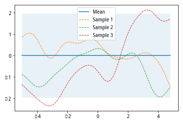

```python
%matplotlib inline

from gaussian_processes_util import plot_gp

# 有限个点
X = np.arange(-5, 5, 0.2).reshape(-1, 1)

# 先验的均值和协方差矩阵
mu = np.zeros(X.shape)
cov = kernel(X, X)

# 抽取先验函数的三个样本
samples = np.random.multivariate_normal(mu.ravel(), cov, 3)

# 绘制GP 均值，置信区间和样本
plot_gp(mu, cov, X, samples=samples)
```

### 基于无噪声训练数据的预测

为了能计算得到后验预测分布的充分统计量：均值和协方差，我们来实现方程 $(4)$ 和 $(5)$

```python
from numpy.linalg import inv

def posterior_predictive(X_s, X_train, Y_train, l=1.0, sigma_f=1.0, sigma_y=1e-8):
    '''
    根据m维训练数据 X_train， Y_train 和n维新输入数据 X_s，
    计算GP后验预测分布的充分统计量


    参数:
        X_s: 新的输入位置 (n x d).
        X_train: 训练位置 (m x d).
        Y_train: 训练目标值 (m x 1).
        l: 核的长度参数.
        sigma_f: 核的垂直振幅参数.
        sigma_y: 噪声参数.

    Returns:
        后验均值向量 (n维) 和 协方差矩阵 (n x n 维).
    '''
    K = kernel(X_train, X_train, l, sigma_f) + sigma_y**2 * np.eye(len(X_train))
    K_s = kernel(X_train, X_s, l, sigma_f)
    K_ss = kernel(X_s, X_s, l, sigma_f) + 1e-8 * np.eye(len(X_s)) # 这里也可假设噪声和K的一致，则1e-8换为sigma_y**2
    K_inv = inv(K)

    #方程 (4)
    mu_s = K_s.T.dot(K_inv).dot(Y_train)

    #方程 (5)
    cov_s = K_ss - K_s.T.dot(K_inv).dot(K_s)

    return mu_s, cov_s
```

并将其应用于无噪声训练数据 `X_train` 和 `Y_train`. 下面的例子从后验预测中抽取了三个样本，并把它们和均值，置信区间，以及训练数据一起画出来。在无噪声模型中，训练点的方差为0，所有从后验得到的随机函数都经过训练点。

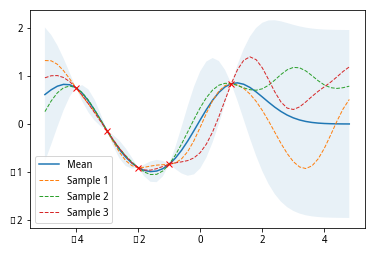

```python
# 无噪声训练数据
X_train = np.array([-4, -3, -2, -1, 1]).reshape(-1, 1)
Y_train = np.sin(X_train)

# 计算后验预测分布的均值与方差
mu_s, cov_s = posterior_predictive(X, X_train, Y_train)

samples = np.random.multivariate_normal(mu_s.ravel(), cov_s, 3)
plot_gp(mu_s, cov_s, X, X_train=X_train, Y_train=Y_train, samples=samples)
```

### 基于噪声训练数据的预测

如果模型中含有一定的噪声，那么训练点只是近似的，训练点的方差不为零。

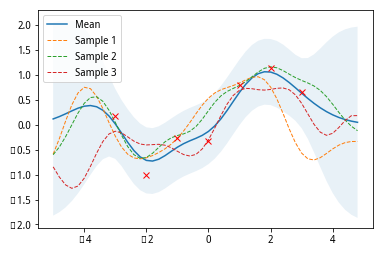

```python
noise = 0.4

# 有噪声的训练数据
X_train = np.arange(-3, 4, 1).reshape(-1, 1)
Y_train = np.sin(X_train) + noise * np.random.randn(*X_train.shape)

# 计算后验预测分布的均值与方差
mu_s, cov_s = posterior_predictive(X, X_train, Y_train, sigma_y=noise)

samples = np.random.multivariate_normal(mu_s.ravel(), cov_s, 3)
plot_gp(mu_s, cov_s, X, X_train=X_train, Y_train=Y_train, samples=samples)
```

### 核参数和噪声参数的影响

以下示例显示了核参数 $l$ 和 $\sigma_f$ 以及噪声参数 $\sigma_y$的影响。 $l$ 值越大，函数越平滑，对训练数据做更粗略的近似拟合；$l$ 值越小，函数越波动，在训练数据点之间具有较宽的置信区间。 $\sigma_f$ 控制从GP中抽取出来的函数的垂直振幅。这可以从第二行右图中训练数据区域左右两侧之外更宽的置信区间看出来。$\sigma_y$ 代表了训练数据中的噪声。$\sigma_y$ 值越大，会得到更粗略的近似拟合，从而避免过拟合含有噪声的数据。

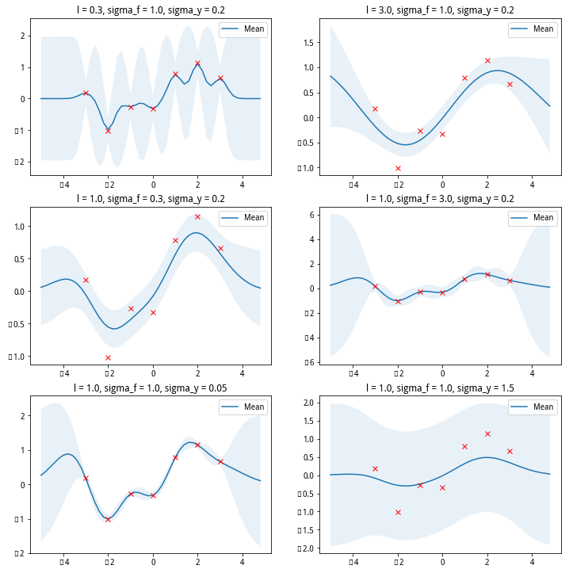

```python
import matplotlib.pyplot as plt

params = [
    (0.3, 1.0, 0.2),
    (3.0, 1.0, 0.2),
    (1.0, 0.3, 0.2),
    (1.0, 3.0, 0.2),
    (1.0, 1.0, 0.05),
    (1.0, 1.0, 1.5),
]

plt.figure(figsize=(12, 5))

for i, (l, sigma_f, sigma_y) in enumerate(params):
    mu_s, cov_s = posterior_predictive(X, X_train, Y_train, l=l,
                                       sigma_f=sigma_f,
                                       sigma_y=sigma_y)
    plt.subplot(3, 2, i + 1)
    plt.subplots_adjust(top=2)
    plt.title(f'l = {l}, sigma_f = {sigma_f}, sigma_y = {sigma_y}')
    plot_gp(mu_s, cov_s, X, X_train=X_train, Y_train=Y_train)
```

可以通过最大化边际对数似然（由<sup>[1] [3]</sup>给出）来估计这些参数的最优值。 $$ \log p(\mathbf{y} \lvert \mathbf{X}) = \log \mathcal{N}(\mathbf{y} \lvert \boldsymbol{0},\mathbf{K}_y) = -\frac{1}{2} \mathbf{y}^T \mathbf{K}_y^{-1} \mathbf{y} -\frac{1}{2} \log \begin{vmatrix}\mathbf{K}_y\end{vmatrix} -\frac{N}{2} \log(2\pi) \tag{7} $$

下面我们将最小化负边际对数似然 w.r.t. 参数 $l$ 和 $\sigma_f$, $\sigma_y$ 被设为数据的已知噪声水平，如果噪声水平未知，$\sigma_y$ 也可以和其他参数一起被估计。

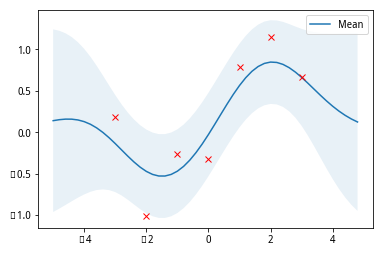

```python
from numpy.linalg import cholesky, det, lstsq
from scipy.optimize import minimize

def nll_fn(X_train, Y_train, noise, naive=True):
    '''
    返回一个函数，用于计算训练数据X_train和Y_train的负边际对数似然和给定的噪声级别。

    Args:
        X_train: 训练位置 (m x d).
        Y_train: 训练目标 (m x 1).
        noise: 已知Y_train的噪声水平
        naive: 如果为True使用方程(7)的简单实现，如果False则使用方程(7)的数值上更稳定的方式实现。

    Returns:
        最小化目标.
    '''
    def nll_naive(theta):
        # 对于本文中的示例，使用方程(7)的简单实现效果很好，但是与下面的使用nll_stable实现相比，它在数值上不那么稳定。
        K = kernel(X_train, X_train, l=theta[0], sigma_f=theta[1]) + \
            noise**2 * np.eye(len(X_train))
        return 0.5 * np.log(det(K)) + \
               0.5 * Y_train.T.dot(inv(K).dot(Y_train)) + \
               0.5 * len(X_train) * np.log(2*np.pi)

    def nll_stable(theta):
        # 如http://www.gaussianprocess.org/gpml/chapters/RW2.pdf，第2.2节，算法2.1所述，
        # 在数值上更稳定地实现方程(7)
        K = kernel(X_train, X_train, l=theta[0], sigma_f=theta[1]) + \
            noise**2 * np.eye(len(X_train))
        L = cholesky(K)
        return np.sum(np.log(np.diagonal(L))) + \
               0.5 * Y_train.T.dot(lstsq(L.T, lstsq(L, Y_train)[0])[0]) + \
               0.5 * len(X_train) * np.log(2*np.pi)

    if naive:
        return nll_naive
    else:
        return nll_stable

# Minimize the negative log-likelihood w.r.t. parameters l and sigma_f.
# We should actually run the minimization several times with different
# initializations to avoid local minima but this is skipped here for
# simplicity.
res = minimize(nll_fn(X_train, Y_train, noise), [1, 1],
               bounds=((1e-5, None), (1e-5, None)),
               method='L-BFGS-B')

# Store the optimization results in global variables so that we can
# compare it later with the results from other implementations.
l_opt, sigma_f_opt = res.x
l_opt, sigma_f_opt

# Compute the prosterior predictive statistics with optimized kernel parameters and plot the results
mu_s, cov_s = posterior_predictive(X, X_train, Y_train, l=l_opt, sigma_f=sigma_f_opt, sigma_y=noise)
plot_gp(mu_s, cov_s, X, X_train=X_train, Y_train=Y_train)
```

在核参数优化的情况下，训练数据被95%置信区间合理覆盖，后验预测的均值是达到了很好的近似拟合。

### 更高的维度

以上实现还可用于更高的输入数据维度。 这里，GP被用来拟合从 $\boldsymbol{0}$ 开始并在x-y平面上展开的正弦波的含噪声样本。下图展示了噪声样本和核参数优化前后的后验预测均值。

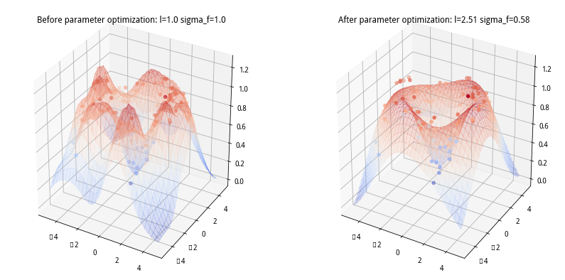

```python
from gaussian_processes_util import plot_gp_2D

noise_2D = 0.1

rx, ry = np.arange(-5, 5, 0.3), np.arange(-5, 5, 0.3)
gx, gy = np.meshgrid(rx, rx)

X_2D = np.c_[gx.ravel(), gy.ravel()]

X_2D_train = np.random.uniform(-4, 4, (100, 2))
Y_2D_train = np.sin(0.5 * np.linalg.norm(X_2D_train, axis=1)) + \
             noise_2D * np.random.randn(len(X_2D_train))

plt.figure(figsize=(14,7))

mu_s, _ = posterior_predictive(X_2D, X_2D_train, Y_2D_train, sigma_y=noise_2D)
plot_gp_2D(gx, gy, mu_s, X_2D_train, Y_2D_train,
           f'Before parameter optimization: l={1.00} sigma_f={1.00}', 1)

res = minimize(nll_fn(X_2D_train, Y_2D_train, noise_2D), [1, 1],
               bounds=((1e-5, None), (1e-5, None)),
               method='L-BFGS-B')

mu_s, _ = posterior_predictive(X_2D, X_2D_train, Y_2D_train, *res.x, sigma_y=noise_2D)
plot_gp_2D(gx, gy, mu_s, X_2D_train, Y_2D_train,
           f'After parameter optimization: l={res.x[0]:.2f} sigma_f={res.x[1]:.2f}', 2)
```

注意，在参数优化后，真实正弦波的逼近效果要好得多。

## 实现GPs的库

本节将演示一个提供GPs实现的库示例。示例中将只提供最简单的设置，但足以复现上面的结果。有关进一步的详细信息，请参阅这些库的官方文档。

### Scikit-learn

Scikit-learn为实现[GP回归模型](http://scikit-learn.org/stable/modules/gaussian_process.html#gaussian-process-regression-gpr)提供了一个高斯过程回归器`GaussianProcessRegressor`。它可以配置[预定义内核和用户定义内核](http://scikit-learn.org/stable/modules/gaussian_process.html#gp-kernels)。内核还可以是复合的（由多个核组合而成）。在scikit-learn中，平方指数核就是`RBF`核。RBF内核只有一个与上面的 $l$ 参数相对应的length_scale参数。为了能有 $\sigma_f$ 参数，我们必须使用复合内核（由`RBF`核与`ConstantKernel`核组成）。

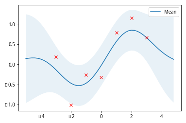

```python
from sklearn.gaussian_process import GaussianProcessRegressor
from sklearn.gaussian_process.kernels import ConstantKernel, RBF

rbf = ConstantKernel(1.0) * RBF(length_scale=1.0)
gpr = GaussianProcessRegressor(kernel=rbf, alpha=noise**2)

# 复用前面1维示例中的训练数据
gpr.fit(X_train, Y_train)

# 计算后验预测的均值和方差
mu_s, cov_s = gpr.predict(X, return_cov=True)

# 获得优化后的核参数
l = gpr.kernel_.k2.get_params()['length_scale']
sigma_f = np.sqrt(gpr.kernel_.k1.get_params()['constant_value'])

# 与之前的结果作比较
assert(np.isclose(l_opt, l))
assert(np.isclose(sigma_f_opt, sigma_f))

# 绘制结果
plot_gp(mu_s, cov_s, X, X_train=X_train, Y_train=Y_train)
```

## 参考文献

[1] Kevin P. Murphy. [Machine Learning, A Probabilistic Perspective](https://mitpress.mit.edu/books/machine-learning-0), Chapters 4, 14 and 15.  
[2] Christopher M. Bishop. [Pattern Recognition and Machine Learning](http://www.springer.com/de/book/9780387310732), Chapter 6.  
[3] Carl Edward Rasmussen and Christopher K. I. Williams. [Gaussian Processes for Machine Learning](http://www.gaussianprocess.org/gpml/).